# Introducción a ggplot2

25/11/2019

## Introducción a visualización de datos en R

https://raw.githubusercontent.com/ft-interactive/chart-doctor/master/visual-vocabulary/poster.png

[figure not shown]

## Introducción a GGPLOT2!

- Librería ggplot2 es una de las librerías más usadas en R para la visualización de datos.
- Existe mucha bibliografía (y códigos) sobre el uso de R:
  - Chang, Winston. 2012. R Graphics Cookbook. Sebastopol, CA: O’Reilly Media
  - Field, Andy P. 2012. Discovering statistics using R. London; Thousand Oaks, Calif: Sage.
  - Wickham, Hadley. 2009. Ggplot2: elegant graphics for data analysis. New York: Springer.
- El objetivo de esta sección es que puedan conocer la estructura del script para ggplot2.

[figure not shown]

## Empezamos!

- Descarguen el script: “ggplot2.R”

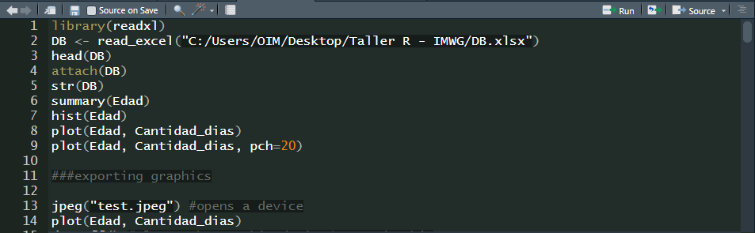

## Instalación de paquetes

- readxl, ggplot2, scales, esquisse

**Base de datos a usar “DB” - Data sobre población venezolana en Tacna**

Los datos se encuentran en un archivo excel y tienen las siguientes variables:

-Edad, Sexo, Embarazada, Estudios, Documento, Fecha de llegada, Cantidad de días, Dinero disponible.

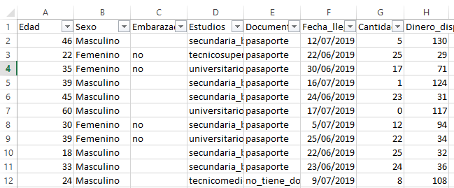

## Gráficos básicos en R

Histograma

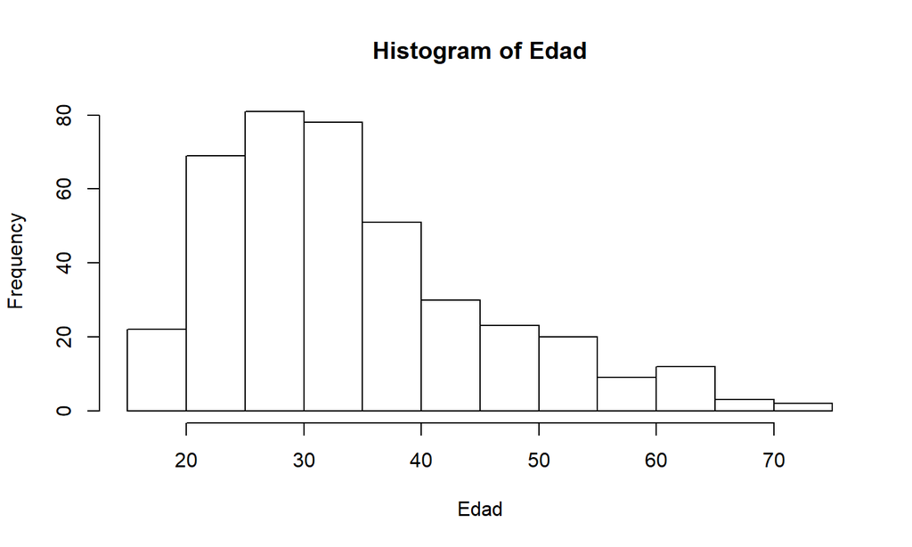

## Utilizando “GGPLOT2”

Estructura del script: Estéticas, capas y facetas

Primer gráfico de Gráfico de barras con la variable Sexo

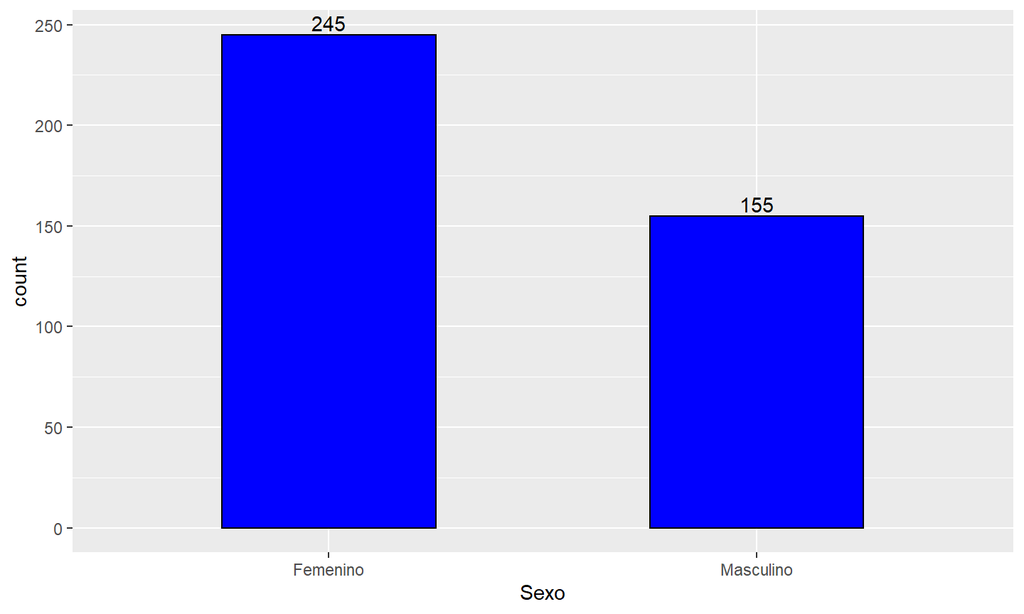

## Complementando el gráfico de barras

Editando límites, títulos, etiquetas de barras, temas

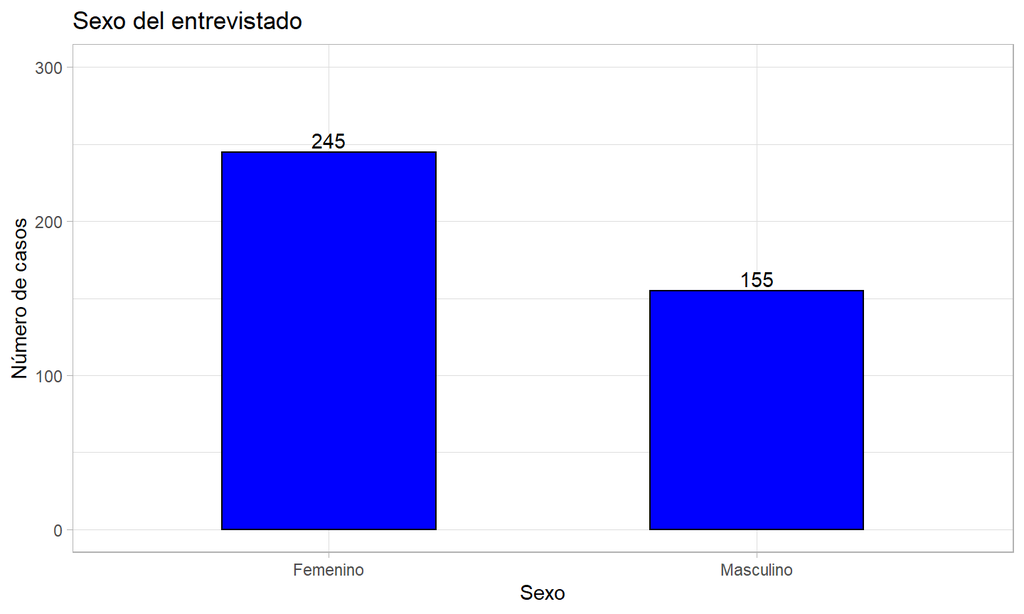

## Realizando gráficos con porcentaje

Para realizar este gráfico es necesario realizar un cálculo de los procentajes

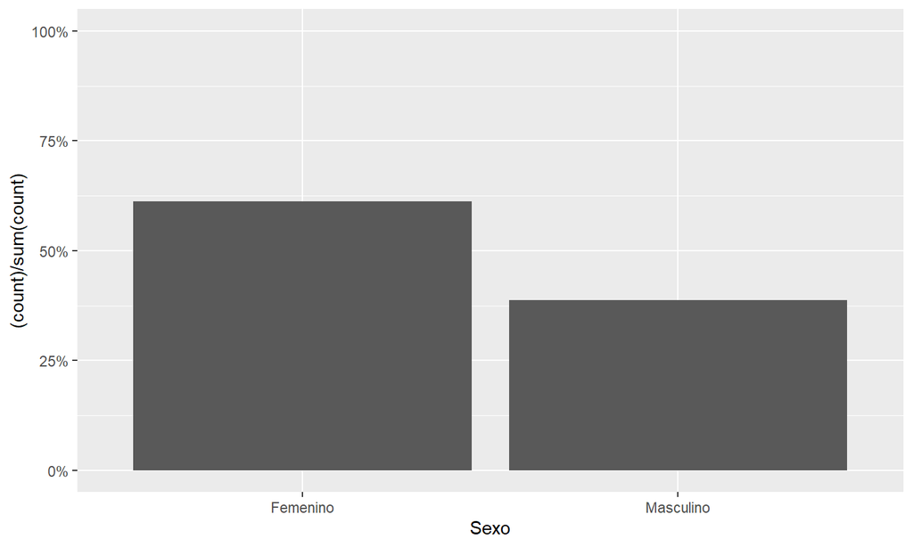

## Nuevos gráficos y utilización de facetas

- Histograma, Curva de densidad , Diagrama de dispersión y Series de tiempo

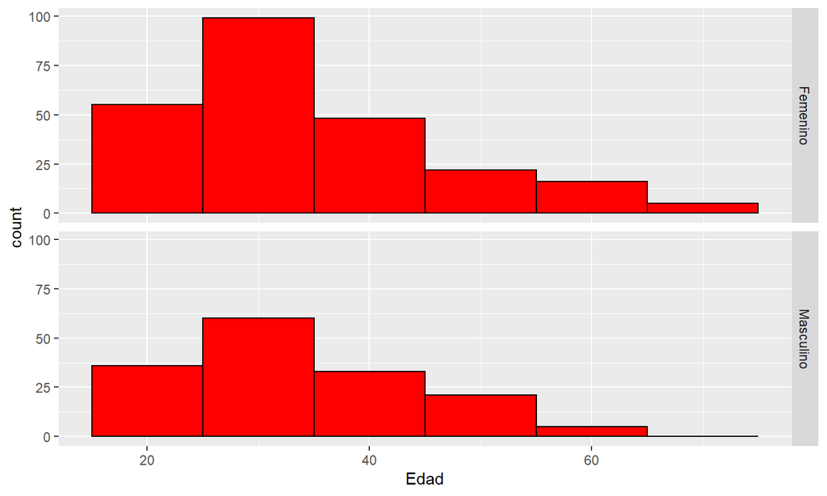

## Curva de densidad

- Utilizando las variables Edad y Sexo

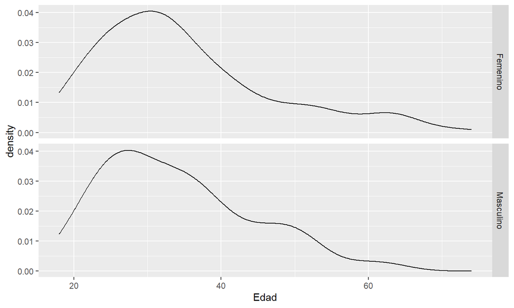

## Diagrama de dispersión

- Utilizando las variables Edad y Cantidad de días.

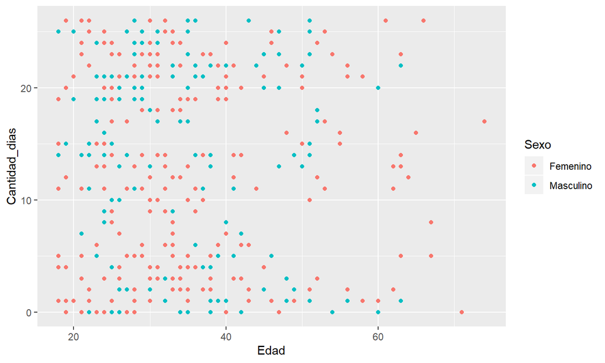

## Series de tiempo

Utilizando las variables Fechas de llegada y Dinero disponible

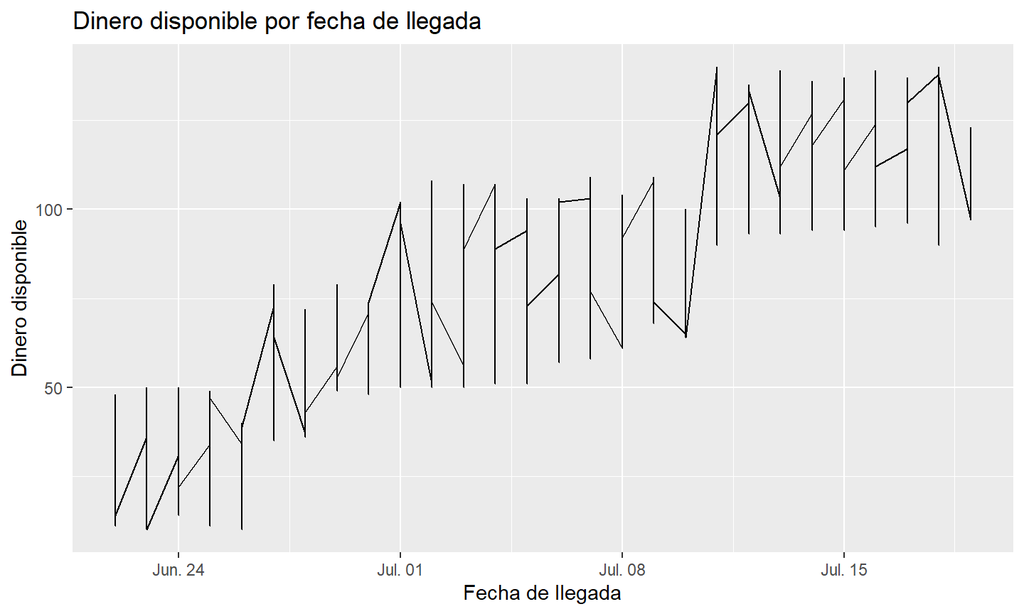

## Dashboards de apoyo para desarrollar gráficos en ggplot2

**Esquisse** - library(esquisse) - esquisse::esquisser()

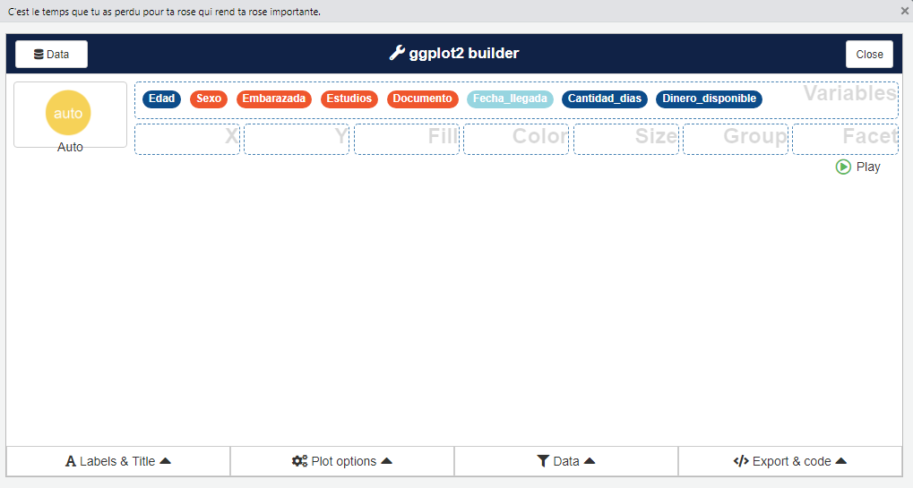

## Potencialidad de la librería ggplot2

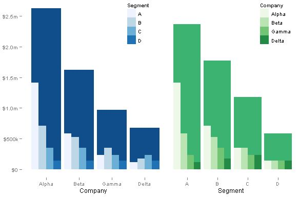

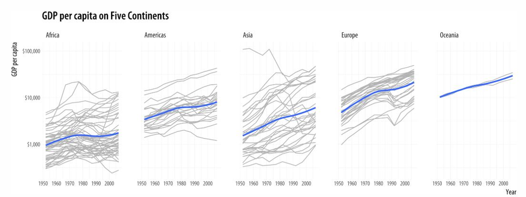